# Formula 1 Racing: Does the car or the driver have the greater impact?

## Data Background

#### Context

The Formula 1 World Championship has been one of the premier forms of auto racing around the world since its first season in 1950. The word “formula” refers to the set of rules that the participants’ cars must conform to. Each Formula 1 season consists of a series of Grands Prix races that take place worldwide on racing circuits and closed public roads. Formula 1 is one of the most popular sports in the world, with over [450 million TV viewers](https://digital.hbs.edu/platform-digit/submission/formula-1-speeding-towards-esports-success/) in 2020.

#### Data Source

The [Formula 1 World Championships](https://www.kaggle.com/rohanrao/formula-1-world-championship-1950-2020) dataset consists of all information on the Formula 1 races, drivers, constructors, qualifying, circuits, lap times, pit stops, and championships for every season from 1950 to 2020.

This dataset was published by Rohan Rao, a Data Scientist who goes by the name [Vopani](https://www.kaggle.com/rohanrao) on Kaggle. (Fun fact: he is also the reigning National Sudoku Champion of India.) He compiled this dataset using the [Ergast Developer API](http://ergast.com/mrd/), an experimental web service that provides a historical record of motor racing data for non-commercial purposes. The API provides data specifically for the Formula One series, from the beginning of the world championships in 1950 up to the present season.

The Ergast API website does not give any details about their data collection procedures, but their data is very thorough and complete. Additionally, Formula 1 world championships are internationally televised and race results are publicly accessible information [(see official Formula 1 website)](https://www.formula1.com/en/results.html), so there is no reason to doubt the accuracy of the data reported.

## Investigation Question

#### Does the car or the driver have the greater impact?

Unlike most sports, Formula 1 racing is heavily reliant on the performance capability of their equipment, which is their cars that are created by the constructors. To what extent do the constructor and driver predict race performance, and which one has the greater predictive capability?

## Data Tidying

The data came in many separate files, including `results.csv`, `drivers.csv`, `constructors.csv`, `circuits.csv`, `races.csv`, `status.csv`, and `laptimes.csv`. Our first step was to join all of these data frames together by their relevant ID numbers and replace the missing values with `NA`.

In our dataset we kept these columns:

- `raceId` & `race_name` The ID number and corresponding name of the race
- `driverId` & `driver_name` The ID number and corresponding driver’s name
- `constructorId` & `constructor_name` The car constructor’s ID number and name
- `positionOrder` The final position order of the race, describing the order the racers finished in.
  - Racers that completed the most laps and in the fastest time receive the highest positions.
- `laps` The number of full laps completed
- `fastestLapSpeed` The speed in km/hr of the racer’s fastest lap of the race
- `statusId` & `status` The status ID number and name.
  - Examples of status name: “Finished”, “Collision”, “Disqualified”, or “Engine” (experienced engine problems)
- `year` The year of the race
- `circuitId` & `circuit_name` The circuit’s ID number and corresponding name

#### Time data

The column `milliseconds` reports the race completion time for all of the drivers that were able to finish the race. However, drivers are often unable to complete the full race due to collisions, car breakdowns, or other problems, leaving many missing values for total race time. We discarded `milliseconds` and created a second dataset where we supplemented information from `laptimes.csv` to compute total race time even when race status was not finished. The lap times were understandably missing when the number of laps completed was 0, so we removed these observations. Overall, we still only have lap times for 9,233 of our 24,900 though.

In this time-filtered dataset we added these columns:

- `total_time` The total time of a race in milliseconds
- `avg_lap` The average lap time for an individual race in milliseconds
- `circuit_avg_lap` The average lap time for a individual circuit in milliseconds
- `circuit_lap_sd` The standard deviation of the average lap time in milliseconds
- `std_avg_lap` The standardized average lap time [unitless]

#### Changes in racing ruleset/vehicle design through the years

This data is for 70 years of races and over that period of time [formula racing has changed a lot](https://youtu.be/hgLQWIAaCmY). This means that many factors will change through the years depending on the rule set that has been put in place. To help mitigate this problem we decided to filter down to the subset of data which follows the most recent set of rules for the races. The [most recent significant set of rules](https://en.wikipedia.org/wiki/Formula_One_engines#2014%E2%80%932021) dates back to 2014 where the allowed engine specifications were changed. Thus we filtered our data to only examine the data from 2014 onwards.

#### Potential Problems

- Some examples of [constructor name changes](https://www.reddit.com/r/formula1/comments/1dos3r/i_made_a_diagram_to_show_how_current_f1_teams/)
  - Our dataset does not include the aliases or previous names of constructors, so we are unable to account for this relationship.
- New drivers are skewed because they don’t have as many data points yet
  - The more datapoints we have on each driver, the better we can characterize their performance. New drivers have fewer known datapoints, so their predictions will have a higher level of uncertainty.
- Teams and drivers are correlated, in that the best drivers tend to get hired by the best teams
  - This confluence between team and driver may make it difficult to separate the impact of driver and constructor.

## Exploratory Data Analysis

#### Standardized Average Lap Time

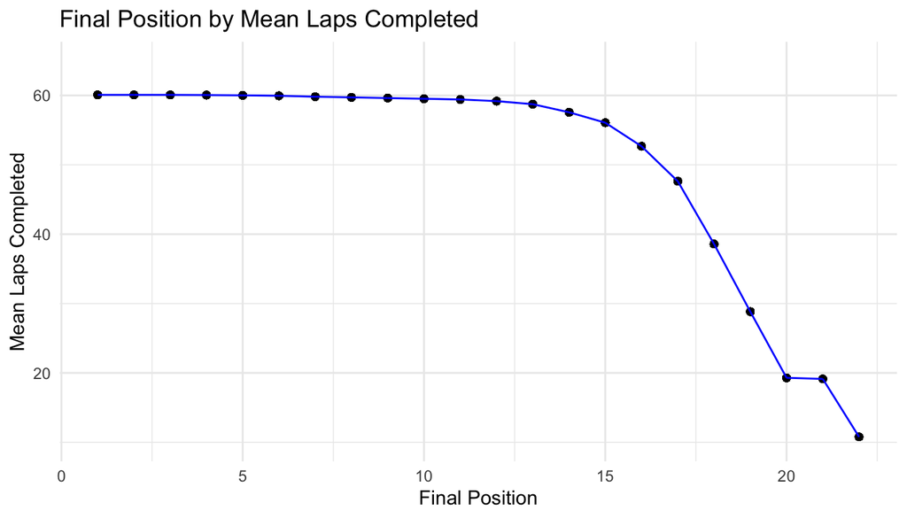

| percent_finishrace |
| --- |
| 80.44814 |

Final position is heavily reliant on how many laps the driver was able to complete, and almost a fifth of the time collisions or car troubles put drivers out of commission before the race is finished. Final position is not reflective of how well the driver was performing before an incident happens, so we decided to use average lap time to create a new metric.

Average lap time is a comprehensive measure of how well a driver performed in a race because it is informed only on the laps they were able to complete, unlike final position. The only problem is that it doesn’t account for the effect of circuit on lap time, so we need to correct for this difference across circuits.

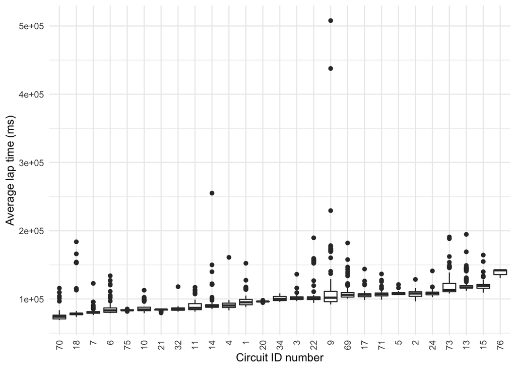

The average lap time varies across circuits due to the differences in track length and shape, so we need a way to compare average lap time across circuits. Dividing average lap time by average lap time per circuit doesn’t work because it doesn’t account for the range of average lap time on each circuit. To correct for the impact of circuit on average lap time, we standardized by circuit:

$$\mu = \sum_{i}^{n} \frac{x_i}{n}$$

$$\sigma = \sqrt{\sum_{i}^{n} \frac{(x_i - \mu)^2}{n}}$$

$$z = \frac{x-\mu}{\sigma}$$

where $x$ is the data, $\mu$ is the mean, $\sigma$ is the standard deviation, and $z$ is the standard score of $x$

#### Standardized Average Lap Time by Circuit

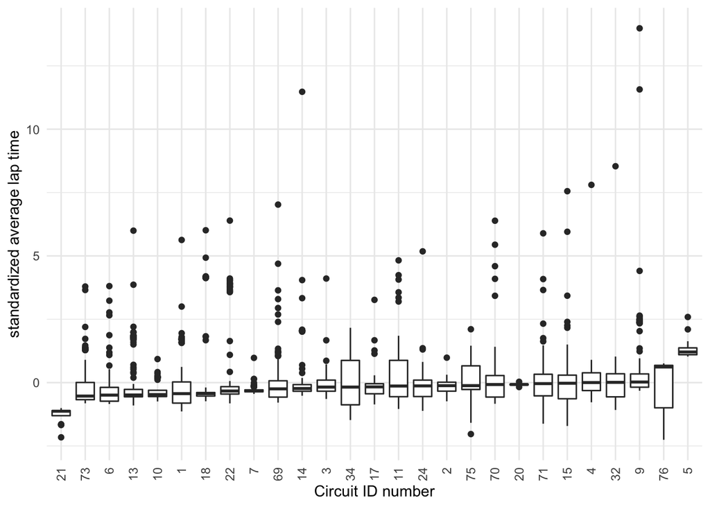

The graph above shows a visual comparison of standardized average lap time by circuit. The slope of the median is small in magnitude relative to the range of the standardized average lap time, showing that standardizing the average lap time successfully minimizes the effect of circuit.

#### Modeling by Standardized Average Lap Time

First, let’s model the a subset of the data that has completed times to get a sense of how informative a linear model of **standardized average lap time** is for our dataset, solely based upon driver, constructor, and a combination of the two.

```
## Subset Fit - Just Driver
```

```
##   Rsquare 0.05762464
```

```
##   MSE 1.133674
```

```
## Subset Fit - Just Constructor
```

```
##   Rsquare 0.04821027
```

```
##   MSE 1.145
```

```
## Subset Fit - Driver and Constructor
```

```
##   Rsquare 0.08991716
```

```
##   MSE 1.094826
```

Starting with looking at the mean square error (MSE) we can compare the different fits against one another. Between fits, the error is lowest with both *driver and constructor*. The “goodness of fit” is best with both factors involved, which may imply that both are informative towards standard average lap time. However, the difference is quite small between MSEs, so the predictive capabilities of both still seem minute. The order of best to worst fit, solely based upon MSE, is **driver and constructor, just driver, and just constructor.** These results may imply that driver is a better predictor of outcome than constructor, but this is not necessarily the case.

Looking next at our R-square value we see that our models *does not* encapsulate much of the variance of the data. We see the fraction of the variance of the data ranges from 4.8% to 8.9%. The order of best to worst fit, solely based upon R-square, is **driver and constructor, just driver, and finally just constructor.**

These models should be taken with a grain or more of salt as we are using the entire subset of data set to create them, so they are extremely optimistic with the fit and do not cover all observations available. Also, as we see from our R-square values, using driver and/or constructor does not seem very fruitful for modeling standardized average lap time. While this was a useful metric for comparing across circuits, it does not seem to be as useful for modeling. Instead, we should explore other variables to indicate performance.

## Final Position Order

#### Driver and Constructor by Final Position Order

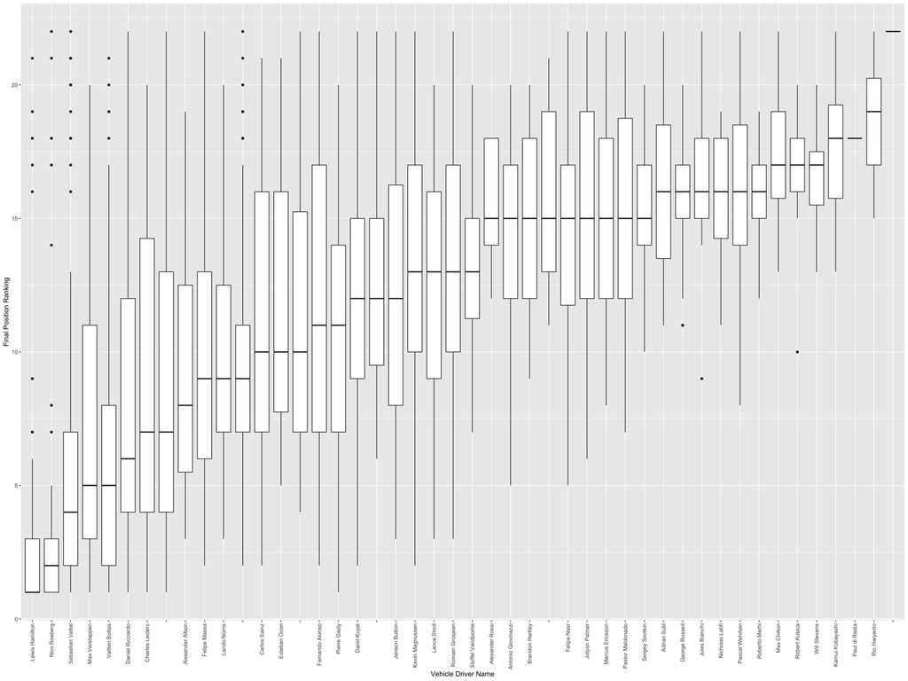

We can see that when we plot the final position vs the driver of the vehicle there does seem to be a correlation. in that some drivers tend to outperform the average and some drivers tend to underperform the average. If we examine the names, the highly performing racers tend to be the racers more well renown for their skill, such as [Lewis Hamilton](https://en.wikipedia.org/wiki/Lewis_Hamilton) and [Nico Rosberg](https://en.wikipedia.org/wiki/Nico_Rosberg). This suggests that there is a correlation between the driver performance and the standing in the race, and that we can see this play out in the relatively linear relation between the two variables. An interesting relation we can see in the data are ‘plateaus’ in the median values where there are sets of drivers with similar performance.

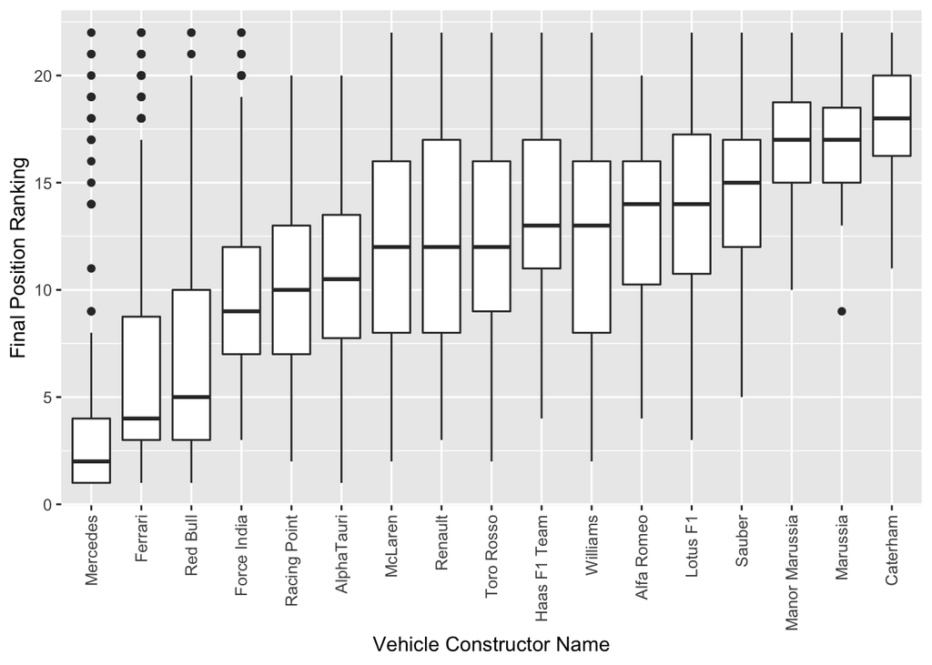

When we plot the constructor by the final position order, we see generally that the higher performing constructors are associated with lower position order, and the lower performing constructors are associated with higher position order. However this is not a linear relationship. The highest performing constructors account for most of the low final position orders and the lowest performing constructors account for much of the high final position orders, but middle performing constructors all seem to have similar performance.

Taken together we can see that the driver and constructor graphs are correlated with the final position order so it is likely that both of them help account for the final position order, but are not the sole determining factors. The more linear relationship of driver with final position order suggests that the driver is slightly more predictive of the final position order than the less linear vehicle constructor.

#### Modeling by Final Position Order

```
## Train Fit - Just Driver
```

```
##   Rsquare 0.3464126
```

```
##   MSE 23.39755
```

```
## Train Fit - Just Constructor
```

```
##   Rsquare 0.3488549
```

```
##   MSE 23.30775
```

```
## Train Fit - Driver and Constructor
```

```
##   Rsquare 0.3817959
```

```
##   MSE 22.13336
```

After multiple samples we see that the R-squared values for just driver and just constructor tend to range from 30% to 37% and a MSE that ranges from 22 to 24. The just driver and just constructor fits seem to be very close in R-squared values and MSE to one another and there is no significant difference between the two.

In comparison, driver and constructor has an R-squared value that tends to range from 33% to 41% and a MSE of 20 to 23. The driver and constructor fit tends to always be better than either the just driver or just constructor fit. Overall, the the range of values for the driver and constructor fit is promising given the multitude of outside factors in racing that are not covered by the investigated factors.

#### Predicted vs Actual Final Position Order

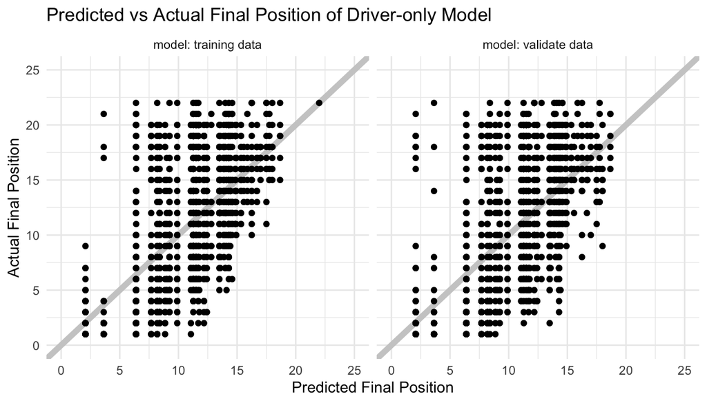

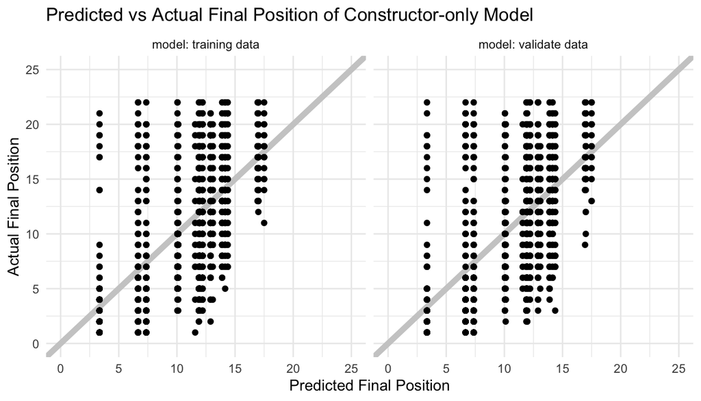

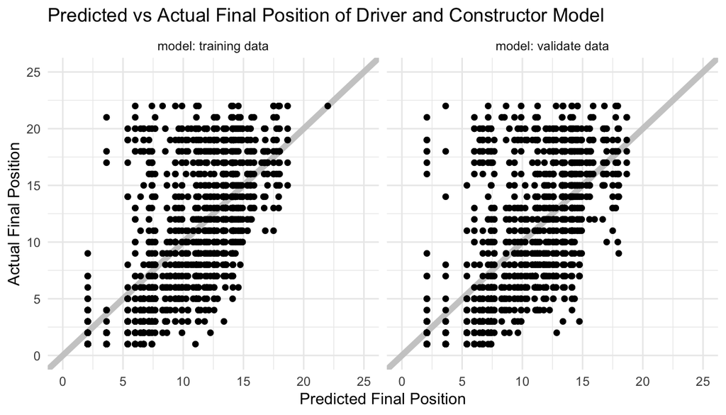

Above are the visualizations of the actual vs. predicted final position of our three linear models, with a line through the axis of symmetry showing where the predicted and actual positions are equal. Comparing the distance from each datapoint to the line of symmetry, we can see that there is a weak linear correlation between the predicted and actual final position in all three models. Interestingly, the shape of the training data closely resembles the shape of the validation data.

In all of the models, there are very few predicted final positions below 5th place or above 20th place; nearly all of the predicted positions fall in the middle of the range of possible values. This makes sense, because a driver or constructor’s performance would have to be either consistently great or consistently terrible to have achieved a very high or very low average ranking.

For the model of constructor-only, there are tall vertical stratifications in predicted final position. This is because the range of final positions that each constructor achieves is typically wider than one position value, yet the linear model only assigns a single coefficient to each constructor, causing all of the datapoints of each constructor to assume the constructor’s mean position value. This poor fit is an inherent limitation of reducing the constructors to linear variables. The same problem applies to considering drivers as linear variables.

#### Prediction Intervals

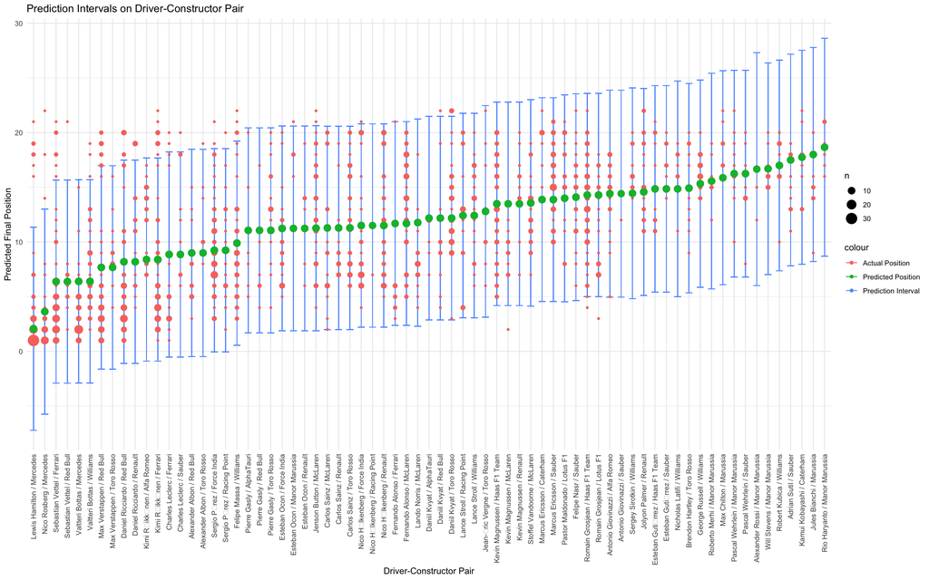

While we are able to compute the prediction intervals on the inputs to our model, we had a hard time creating an effective visual to compare the predictions to actual final position in a meaningful way due to the large number of levels. The graph above shows the position prediction intervals for each driver-constructor pair, ordered from lowest to highest predicted value. Graphing the final position on top of the prediction intervals, we can see that the coverage of the prediction intervals on the validation data is good, with the majority of datapoints falling inside the prediction interval.

However, there is a group of high outliers occurring above several of the driver-constructor pairs with the lowest predicted positions. The prediction intervals with a lower bound below 0 have much less coverage of the actual position data, making up most of the outliers seen. If the predicted value is low, the lower prediction bound will shift into the negative numbers, but achieving a negative position in the race is not possible. Prediction intervals are intended for normally distributed data so the asymmetrical distribution of these driver-constructor pairs renders them less effective.

## Questions Remaining

- Can you visualize rule changes, such as engine specification, on the overall trend of the data?
- Can you look at track changes over the years and effects on lap times?
- How much does starting position have an effect on the final/ending position?
- Using the history of an individual driver’s performances can you predict their lap times in future races?

## Conclusion

Our initial driving question sought to answer whether the car or the driver has a greater impact on overall performance. The answer that we came to is that both have a sizable impact on performance, and their individual significance cannot be easily isolated using simple models. Our models demonstrate that using either driver or constructor on its own is a significant predictor for final position order. (Which one is a better approximation relies on the sampling made in the train-test split). A model using the combination of both variables as a predictor served as the strongest predictor of final position, however it still did not sufficiently account for the final position of the vehicles.

If it is desired to have an accurate predictor of the final position of a Formula 1 race, one should take into account more factors than the two investigated in this project. However, if one wants to know whether the driver or the vehicle is more significant in determining results, the answer is that there is no statistically significant difference between the two factors’ predictive ability to determine race results.